# Project: Wrangling and Analyze Data

```python
# Neccessary packages
import pandas as pd
import numpy as np
import requests
import tweepy
from tweepy import OAuthHandler
from timeit import default_timer as timer
import os
import json as js
from wordcloud import  WordCloud, STOPWORDS, ImageColorGenerator
from PIL import Image
import matplotlib.pyplot as plt
%matplotlib inline
```

## Data Gathering

In the cell below, gather **all** three pieces of data for this project and load them in the notebook. **Note:** the methods required to gather each data are different.

1. Directly download the WeRateDogs Twitter archive data (twitter_archive_enhanced.csv)

```python
tweets_arch = pd.read_csv('twitter-archive-enhanced.csv')
```

1. Use the Requests library to download the tweet image prediction (image_predictions.tsv)

```python
response = requests.get("https://d17h27t6h515a5.cloudfront.net/topher/2017/August/599fd2ad_image-predictions/image-predictions.tsv")
with open("image_predictions.tsv", mode='wb') as file:
    file.write(response.content)

images = pd.read_csv('image_predictions.tsv', sep='\t')
```

1. Use the Tweepy library to query additional data via the Twitter API (tweet_json.txt)

consumer_key = 'XXXXXXXXXX' consumer_secret = 'XXXXXXXXXX' access_token = 'XXXXXXXXXX' access_secret = 'XXXXXXXXXX'

```
auth = OAuthHandler(consumer_key, consumer_secret)
auth.set_access_token(access_token, access_secret)

api = tweepy.API(auth, wait_on_rate_limit=True)
```

#### Query Twitter's API for JSON data for each tweet ID in tweet_archive dataset

```
try:
    tweet = api.get_status(tweet_id, tweet_mode='extended')
    print("Success")
    json.dump(tweet._json, outfile)
    outfile.write('\n')
except tweepy.TweepError as e:
    print("Fail")
    fails_dict[tweet_id] = e
    pass
```

*I don't have access to the twitter API so I used the json dataset provided*

```python
json = pd.read_json('tweet-json.txt', lines=True)
```

```python
tweets_list = []
with open ('tweet-json.txt','r') as file:
    for line in file:
        data = js.loads(line)
        tweets_list.append(data)
        tweet_json = pd.DataFrame(tweets_list, columns = ['id', 'retweet_count', 'favorite_count'])
```

## Assessing Data

In this section, detect and document at least **eight (8) quality issues and two (2) tidiness issue**. You must use **both** visual assessment programmatic assessement to assess the data.

**Note:** pay attention to the following key points when you access the data.

- You only want original ratings (no retweets) that have images. Though there are 5000+ tweets in the dataset, not all are dog ratings and some are retweets.
- Assessing and cleaning the entire dataset completely would require a lot of time, and is not necessary to practice and demonstrate your skills in data wrangling. Therefore, the requirements of this project are only to assess and clean at least 8 quality issues and at least 2 tidiness issues in this dataset.
- The fact that the rating numerators are greater than the denominators does not need to be cleaned. This [unique rating system](http://knowyourmeme.com/memes/theyre-good-dogs-brent) is a big part of the popularity of WeRateDogs.
- You do not need to gather the tweets beyond August 1st, 2017. You can, but note that you won't be able to gather the image predictions for these tweets since you don't have access to the algorithm used.

```python
tweets_arch.head()
```

|  | tweet_id | in_reply_to_status_id | in_reply_to_user_id | timestamp | source | text | retweeted_status_id | retweeted_status_user_id | retweeted_status_timestamp | expanded_urls | rating_numerator | rating_denominator | name | doggo | floofer | pupper | puppo |
| --- | --- | --- | --- | --- | --- | --- | --- | --- | --- | --- | --- | --- | --- | --- | --- | --- | --- |
| 0 | 892420643555336193 | NaN | NaN | 2017-08-01 16:23:56 +0000 | <a href="http://twitter.com/download/iphone" r... | This is Phineas. He's a mystical boy. Only eve... | NaN | NaN | NaN | https://twitter.com/dog_rates/status/892420643... | 13 | 10 | Phineas | None | None | None | None |
| 1 | 892177421306343426 | NaN | NaN | 2017-08-01 00:17:27 +0000 | <a href="http://twitter.com/download/iphone" r... | This is Tilly. She's just checking pup on you.... | NaN | NaN | NaN | https://twitter.com/dog_rates/status/892177421... | 13 | 10 | Tilly | None | None | None | None |
| 2 | 891815181378084864 | NaN | NaN | 2017-07-31 00:18:03 +0000 | <a href="http://twitter.com/download/iphone" r... | This is Archie. He is a rare Norwegian Pouncin... | NaN | NaN | NaN | https://twitter.com/dog_rates/status/891815181... | 12 | 10 | Archie | None | None | None | None |
| 3 | 891689557279858688 | NaN | NaN | 2017-07-30 15:58:51 +0000 | <a href="http://twitter.com/download/iphone" r... | This is Darla. She commenced a snooze mid meal... | NaN | NaN | NaN | https://twitter.com/dog_rates/status/891689557... | 13 | 10 | Darla | None | None | None | None |
| 4 | 891327558926688256 | NaN | NaN | 2017-07-29 16:00:24 +0000 | <a href="http://twitter.com/download/iphone" r... | This is Franklin. He would like you to stop ca... | NaN | NaN | NaN | https://twitter.com/dog_rates/status/891327558... | 12 | 10 | Franklin | None | None | None | None |

```python
tweets_arch.shape
```

```
(2356, 17)
```

```python
tweets_arch.sample(3)
```

|  | tweet_id | in_reply_to_status_id | in_reply_to_user_id | timestamp | source | text | retweeted_status_id | retweeted_status_user_id | retweeted_status_timestamp | expanded_urls | rating_numerator | rating_denominator | name | doggo | floofer | pupper | puppo |
| --- | --- | --- | --- | --- | --- | --- | --- | --- | --- | --- | --- | --- | --- | --- | --- | --- | --- |
| 1046 | 743545585370791937 | NaN | NaN | 2016-06-16 20:47:36 +0000 | <a href="http://twitter.com/download/iphone" r... | Say hello to Bentley and Millie. They do every... | NaN | NaN | NaN | https://twitter.com/dog_rates/status/743545585... | 11 | 10 | Bentley | None | None | None | None |
| 775 | 776201521193218049 | NaN | NaN | 2016-09-14 23:30:38 +0000 | <a href="http://twitter.com/download/iphone" r... | This is O'Malley. That is how he sleeps. Doesn... | NaN | NaN | NaN | https://twitter.com/dog_rates/status/776201521... | 10 | 10 | O | None | None | None | None |
| 759 | 778396591732486144 | NaN | NaN | 2016-09-21 00:53:04 +0000 | <a href="http://twitter.com/download/iphone" r... | RT @dog_rates: This is an East African Chalupa... | 7.030419e+17 | 4.196984e+09 | 2016-02-26 02:20:37 +0000 | https://twitter.com/dog_rates/status/703041949... | 10 | 10 | an | None | None | None | None |

```python
# checking for data types and null values
tweets_arch.info()
```

```
<class 'pandas.core.frame.DataFrame'>
RangeIndex: 2356 entries, 0 to 2355
Data columns (total 17 columns):
tweet_id                      2356 non-null int64
in_reply_to_status_id         78 non-null float64
in_reply_to_user_id           78 non-null float64
timestamp                     2356 non-null object
source                        2356 non-null object
text                          2356 non-null object
retweeted_status_id           181 non-null float64
retweeted_status_user_id      181 non-null float64
retweeted_status_timestamp    181 non-null object
expanded_urls                 2297 non-null object
rating_numerator              2356 non-null int64
rating_denominator            2356 non-null int64
name                          2356 non-null object
doggo                         2356 non-null object
floofer                       2356 non-null object
pupper                        2356 non-null object
puppo                         2356 non-null object
dtypes: float64(4), int64(3), object(10)
memory usage: 313.0+ KB
```

```python
# check for duplicates
tweets_arch.duplicated().sum()
```

```
0
```

```python
# summary statistics of rating denominator
tweets_arch.rating_denominator.describe()
```

```
count    2356.000000
mean       10.455433
std         6.745237
min         0.000000
25%        10.000000
50%        10.000000
75%        10.000000
max       170.000000
Name: rating_denominator, dtype: float64
```

```python
# check for where the rating denominator is less than 10
tweets_arch.query('rating_denominator < 10')
```

|  | tweet_id | in_reply_to_status_id | in_reply_to_user_id | timestamp | source | text | retweeted_status_id | retweeted_status_user_id | retweeted_status_timestamp | expanded_urls | rating_numerator | rating_denominator | name | doggo | floofer | pupper | puppo |
| --- | --- | --- | --- | --- | --- | --- | --- | --- | --- | --- | --- | --- | --- | --- | --- | --- | --- |
| 313 | 835246439529840640 | 8.352460e+17 | 26259576.0 | 2017-02-24 21:54:03 +0000 | <a href="http://twitter.com/download/iphone" r... | @jonnysun @Lin_Manuel ok jomny I know you're e... | NaN | NaN | NaN | NaN | 960 | 0 | None | None | None | None | None |
| 516 | 810984652412424192 | NaN | NaN | 2016-12-19 23:06:23 +0000 | <a href="http://twitter.com/download/iphone" r... | Meet Sam. She smiles 24/7 &amp; secretly aspir... | NaN | NaN | NaN | https://www.gofundme.com/sams-smile,https://tw... | 24 | 7 | Sam | None | None | None | None |
| 2335 | 666287406224695296 | NaN | NaN | 2015-11-16 16:11:11 +0000 | <a href="http://twitter.com/download/iphone" r... | This is an Albanian 3 1/2 legged Episcopalian... | NaN | NaN | NaN | https://twitter.com/dog_rates/status/666287406... | 1 | 2 | an | None | None | None | None |

```python
# summary stats of rating numerator
tweets_arch.rating_numerator.describe()
```

```
count    2356.000000
mean       13.126486
std        45.876648
min         0.000000
25%        10.000000
50%        11.000000
75%        12.000000
max      1776.000000
Name: rating_numerator, dtype: float64
```

```python
# check for where the rating numerator is less greater than 10
higher_n = tweets_arch.query('rating_numerator > 12')
higher_n.rating_numerator.value_counts()
```

```
13      351
14       54
75        2
15        2
420       2
17        1
20        1
24        1
26        1
27        1
44        1
45        1
50        1
60        1
960       1
84        1
88        1
99        1
121       1
143       1
144       1
666       1
165       1
182       1
204       1
1776      1
80        1
Name: rating_numerator, dtype: int64
```

### IMAGE DATASET

```python
images.head()
```

|  | tweet_id | jpg_url | img_num | p1 | p1_conf | p1_dog | p2 | p2_conf | p2_dog | p3 | p3_conf | p3_dog |
| --- | --- | --- | --- | --- | --- | --- | --- | --- | --- | --- | --- | --- |
| 0 | 666020888022790149 | https://pbs.twimg.com/media/CT4udn0WwAA0aMy.jpg | 1 | Welsh_springer_spaniel | 0.465074 | True | collie | 0.156665 | True | Shetland_sheepdog | 0.061428 | True |
| 1 | 666029285002620928 | https://pbs.twimg.com/media/CT42GRgUYAA5iDo.jpg | 1 | redbone | 0.506826 | True | miniature_pinscher | 0.074192 | True | Rhodesian_ridgeback | 0.072010 | True |
| 2 | 666033412701032449 | https://pbs.twimg.com/media/CT4521TWwAEvMyu.jpg | 1 | German_shepherd | 0.596461 | True | malinois | 0.138584 | True | bloodhound | 0.116197 | True |
| 3 | 666044226329800704 | https://pbs.twimg.com/media/CT5Dr8HUEAA-lEu.jpg | 1 | Rhodesian_ridgeback | 0.408143 | True | redbone | 0.360687 | True | miniature_pinscher | 0.222752 | True |
| 4 | 666049248165822465 | https://pbs.twimg.com/media/CT5IQmsXIAAKY4A.jpg | 1 | miniature_pinscher | 0.560311 | True | Rottweiler | 0.243682 | True | Doberman | 0.154629 | True |

```python
# checking for data types and null values
images.info()
```

```
<class 'pandas.core.frame.DataFrame'>
RangeIndex: 2075 entries, 0 to 2074
Data columns (total 12 columns):
tweet_id    2075 non-null int64
jpg_url     2075 non-null object
img_num     2075 non-null int64
p1          2075 non-null object
p1_conf     2075 non-null float64
p1_dog      2075 non-null bool
p2          2075 non-null object
p2_conf     2075 non-null float64
p2_dog      2075 non-null bool
p3          2075 non-null object
p3_conf     2075 non-null float64
p3_dog      2075 non-null bool
dtypes: bool(3), float64(3), int64(2), object(4)
memory usage: 152.1+ KB
```

```python
# checking for duplicates
images.duplicated().sum()
```

```
0
```

```python
# checking for where the images were predicted as dogs
images.query('p1_dog == True').sum()
```

```
tweet_id                               1138195366274693309382
jpg_url     https://pbs.twimg.com/media/CT4udn0WwAA0aMy.jp...
img_num                                                  1858
p1          Welsh_springer_spanielredboneGerman_shepherdRh...
p1_conf                                               940.377
p1_dog                                                   1532
p2          collieminiature_pinschermalinoisredboneRottwei...
p2_conf                                               216.513
p2_dog                                                   1398
p3          Shetland_sheepdogRhodesian_ridgebackbloodhound...
p3_conf                                               94.6833
p3_dog                                                   1334
dtype: object
```

### TWEET_JSON DATASET

```python
tweet_json.head()
```

|  | id | retweet_count | favorite_count |
| --- | --- | --- | --- |
| 0 | 892420643555336193 | 8853 | 39467 |
| 1 | 892177421306343426 | 6514 | 33819 |
| 2 | 891815181378084864 | 4328 | 25461 |
| 3 | 891689557279858688 | 8964 | 42908 |
| 4 | 891327558926688256 | 9774 | 41048 |

```python
#checking for data types and nulls
tweet_json.info()
```

```
<class 'pandas.core.frame.DataFrame'>
RangeIndex: 2354 entries, 0 to 2353
Data columns (total 3 columns):
id                2354 non-null int64
retweet_count     2354 non-null int64
favorite_count    2354 non-null int64
dtypes: int64(3)
memory usage: 55.2 KB
```

```python
# check summary stats
tweet_json.describe()
```

|  | id | retweet_count | favorite_count |
| --- | --- | --- | --- |
| count | 2.354000e+03 | 2354.000000 | 2354.000000 |
| mean | 7.426978e+17 | 3164.797366 | 8080.968564 |
| std | 6.852812e+16 | 5284.770364 | 11814.771334 |
| min | 6.660209e+17 | 0.000000 | 0.000000 |
| 25% | 6.783975e+17 | 624.500000 | 1415.000000 |
| 50% | 7.194596e+17 | 1473.500000 | 3603.500000 |
| 75% | 7.993058e+17 | 3652.000000 | 10122.250000 |
| max | 8.924206e+17 | 79515.000000 | 132810.000000 |

```python
# checking for duplicates
tweet_json.duplicated().sum()
```

```
0
```

### Quality issues

1. There are retweets present in tweets_arch columns
2. Retweets in rows (rows that start with 'RT @')
3. Timestamp format is object(string) and tweet_id format is int
4. Invalid dog names in tweets_arch
5. Tweet source can be extracted in tweets_arch
6. Inconsistency in p1,p2,p3 string cases in images
7. Outliers in rating_denominator in tweets_arch
8. Outliers in rating_numerator in tweets_arch
9. Some of the values in images are not dogs
10. Some columns are unnecessary for analysis
11. Non descriptive column names

### Tidiness issues

1. The three datasets should be merged as they are part of the same observational unit(tweets)
2. dogstages is spread across four columns instead of one column in tweets_arch

## Cleaning Data

In this section, clean **all** of the issues you documented while assessing.

**Note:** Make a copy of the original data before cleaning. Cleaning includes merging individual pieces of data according to the rules of [tidy data](https://cran.r-project.org/web/packages/tidyr/vignettes/tidy-data.html). The result should be a high-quality and tidy master pandas DataFrame (or DataFrames, if appropriate).

```python
# Make copies of original pieces of data
tweets_clean = tweets_arch.copy()
images_clean = images.copy()
json_clean = tweet_json.copy()
```

### Issue #1: Tidyness

#### Define

Merge the three datasets as they are part of the same observational unit

#### Code

```python
# rename the id column in json_clean for easy merging
json_clean.rename(columns = {'id':'tweet_id'}, inplace = True)

# merge tweets_archive and json dataset
archive_json = pd.merge(tweets_clean, json_clean, on=['tweet_id', 'tweet_id'], how='left')

# merge new df with images data
df = pd.merge(archive_json, images_clean, on =['tweet_id', 'tweet_id'], how='left')
```

#### Test

```python
print(df.shape)
df.head()
```

```
(2356, 30)
```

|  | tweet_id | in_reply_to_status_id | in_reply_to_user_id | timestamp | source | text | retweeted_status_id | retweeted_status_user_id | retweeted_status_timestamp | expanded_urls | ... | img_num | p1 | p1_conf | p1_dog | p2 | p2_conf | p2_dog | p3 | p3_conf | p3_dog |
| --- | --- | --- | --- | --- | --- | --- | --- | --- | --- | --- | --- | --- | --- | --- | --- | --- | --- | --- | --- | --- | --- |
| 0 | 892420643555336193 | NaN | NaN | 2017-08-01 16:23:56 +0000 | <a href="http://twitter.com/download/iphone" r... | This is Phineas. He's a mystical boy. Only eve... | NaN | NaN | NaN | https://twitter.com/dog_rates/status/892420643... | ... | 1.0 | orange | 0.097049 | False | bagel | 0.085851 | False | banana | 0.076110 | False |
| 1 | 892177421306343426 | NaN | NaN | 2017-08-01 00:17:27 +0000 | <a href="http://twitter.com/download/iphone" r... | This is Tilly. She's just checking pup on you.... | NaN | NaN | NaN | https://twitter.com/dog_rates/status/892177421... | ... | 1.0 | Chihuahua | 0.323581 | True | Pekinese | 0.090647 | True | papillon | 0.068957 | True |
| 2 | 891815181378084864 | NaN | NaN | 2017-07-31 00:18:03 +0000 | <a href="http://twitter.com/download/iphone" r... | This is Archie. He is a rare Norwegian Pouncin... | NaN | NaN | NaN | https://twitter.com/dog_rates/status/891815181... | ... | 1.0 | Chihuahua | 0.716012 | True | malamute | 0.078253 | True | kelpie | 0.031379 | True |
| 3 | 891689557279858688 | NaN | NaN | 2017-07-30 15:58:51 +0000 | <a href="http://twitter.com/download/iphone" r... | This is Darla. She commenced a snooze mid meal... | NaN | NaN | NaN | https://twitter.com/dog_rates/status/891689557... | ... | 1.0 | paper_towel | 0.170278 | False | Labrador_retriever | 0.168086 | True | spatula | 0.040836 | False |
| 4 | 891327558926688256 | NaN | NaN | 2017-07-29 16:00:24 +0000 | <a href="http://twitter.com/download/iphone" r... | This is Franklin. He would like you to stop ca... | NaN | NaN | NaN | https://twitter.com/dog_rates/status/891327558... | ... | 2.0 | basset | 0.555712 | True | English_springer | 0.225770 | True | German_short-haired_pointer | 0.175219 | True |

5 rows × 30 columns

### Issue #2:

#### Define

- Write a function that converts dog stages into a single column rather than having the dog stage values as columns, then drop the doggo, floofer, pupper and puppo columns
- This function creates a new column 'dog_stage' and fills it with the value from the either the doggo, floofer, pupper or puppo column, where it is not 'None'.
- If all the values in the rows of the columns are 'None', it replaces with NA.
- If there is more than one null value, it concatenates the values

#### Code

```python
def dogstage(df, columns):
    for column in columns:
        df[column] = df[column].replace('None',np.NaN)
    df["dogstage"] = df[columns].apply(lambda x: ','.join(x.dropna()), axis=1)
    df["dogstage"] = df["dogstage"].replace('', 'NA')
    return df
columns = ['doggo','floofer','pupper','puppo']
df = dogstage(df, columns)
```

```python
#drop the former columns
df = df.drop(['doggo','floofer','pupper','puppo'], axis = 1)
```

#### Test

```python
df.dogstage.value_counts()
```

```
NA               1976
pupper            245
doggo              83
puppo              29
doggo,pupper       12
floofer             9
doggo,floofer       1
doggo,puppo         1
Name: dogstage, dtype: int64
```

### Issue #3: Cleaning for Quality

#### Define

Drop columns with retweets (this also handles missing data)

#### Code

```python
#only original tweets are needed
df = df.drop(['in_reply_to_status_id','in_reply_to_user_id','retweeted_status_id','expanded_urls',
                   'retweeted_status_user_id','retweeted_status_timestamp'], axis =1)
```

#### Test

```python
print(df.columns)
```

```
Index(['tweet_id', 'timestamp', 'source', 'text', 'rating_numerator',
       'rating_denominator', 'name', 'retweet_count', 'favorite_count',
       'jpg_url', 'img_num', 'p1', 'p1_conf', 'p1_dog', 'p2', 'p2_conf',
       'p2_dog', 'p3', 'p3_conf', 'p3_dog', 'dogstage'],
      dtype='object')
```

### Issue #4:

#### Define

Filter rows that are retweets and remove them

#### Code

```python
# check for retweets
df[df['text'].str.contains('RT @')]
```

[output not shown]

181 rows × 21 columns

```python
# remove the retweet rows
df = df.loc[df['text'].str.startswith('RT @')!=True]
```

#### Test

```python
df[df['text'].str.contains('RT @')]
```

|  | tweet_id | timestamp | source | text | rating_numerator | rating_denominator | name | retweet_count | favorite_count | jpg_url | ... | p1 | p1_conf | p1_dog | p2 | p2_conf | p2_dog | p3 | p3_conf | p3_dog | dogstage |
| --- | --- | --- | --- | --- | --- | --- | --- | --- | --- | --- | --- | --- | --- | --- | --- | --- | --- | --- | --- | --- | --- |

0 rows × 21 columns

### Issue #5:

#### Define

Change timestamp column to datetime, change tweet_id column to str

#### Code

```python
# convert timestamp to datetime
df['timestamp'] = pd.to_datetime(df.timestamp)

# convert tweet_id to string
df['tweet_id'] = df.tweet_id.astype(str)
```

#### Test

```python
df.info()
```

```
<class 'pandas.core.frame.DataFrame'>
Int64Index: 2175 entries, 0 to 2355
Data columns (total 21 columns):
tweet_id              2175 non-null object
timestamp             2175 non-null datetime64[ns]
source                2175 non-null object
text                  2175 non-null object
rating_numerator      2175 non-null int64
rating_denominator    2175 non-null int64
name                  2175 non-null object
retweet_count         2175 non-null float64
favorite_count        2175 non-null float64
jpg_url               1994 non-null object
img_num               1994 non-null float64
p1                    1994 non-null object
p1_conf               1994 non-null float64
p1_dog                1994 non-null object
p2                    1994 non-null object
p2_conf               1994 non-null float64
p2_dog                1994 non-null object
p3                    1994 non-null object
p3_conf               1994 non-null float64
p3_dog                1994 non-null object
dogstage              2175 non-null object
dtypes: datetime64[ns](1), float64(6), int64(2), object(12)
memory usage: 373.8+ KB
```

### Issue #6:

#### Define

Remove invalid names like a', 'the', 'such', 'officially' in df

#### Code

```python
# print out invalid names
mask = df.name.str.contains('^[a-z]', regex = True)
df[mask].name.value_counts().sort_index()
```

```
a               55
actually         2
all              1
an               6
by               1
getting          2
his              1
incredibly       1
infuriating      1
just             3
life             1
light            1
mad              1
my               1
not              2
officially       1
old              1
one              4
quite            3
space            1
such             1
the              8
this             1
unacceptable     1
very             4
Name: name, dtype: int64
```

```python
# remove the rows with invalid names
invalid_names = df[mask].name.value_counts()
df = df.query("name not in @invalid_names.index")
```

#### Test

```python
df.query("name in @invalid_names.index")
```

|  | tweet_id | timestamp | source | text | rating_numerator | rating_denominator | name | retweet_count | favorite_count | jpg_url | ... | p1 | p1_conf | p1_dog | p2 | p2_conf | p2_dog | p3 | p3_conf | p3_dog | dogstage |
| --- | --- | --- | --- | --- | --- | --- | --- | --- | --- | --- | --- | --- | --- | --- | --- | --- | --- | --- | --- | --- | --- |

0 rows × 21 columns

### Issue #7:

#### Define

Extract device from source url then drop source column

#### Code

```python
# extract device from source column
df['device'] = df.source.str.extract('(?<=>)(.+?)(?=</a)', expand=True)
df.drop(['source'],axis = 1, inplace = True)
```

#### Test

```python
df.device.value_counts()
```

```
Twitter for iPhone     1947
Vine - Make a Scene      87
Twitter Web Client       27
TweetDeck                10
Name: device, dtype: int64
```

### Issue #8:

#### Define

write a function that takes the values of p1, p2, p3 and turns them title case

#### Code

```python
def titlecase(df, columns):
    for col in columns:
        df[col] = df[col].str.title()
    return df
```

#### Test

```python
titlecase(df, ['p1','p2','p3'])
df.tail(2)
```

|  | tweet_id | timestamp | text | rating_numerator | rating_denominator | name | retweet_count | favorite_count | jpg_url | img_num | ... | p1_conf | p1_dog | p2 | p2_conf | p2_dog | p3 | p3_conf | p3_dog | dogstage | device |
| --- | --- | --- | --- | --- | --- | --- | --- | --- | --- | --- | --- | --- | --- | --- | --- | --- | --- | --- | --- | --- | --- |
| 2351 | 666049248165822465 | 2015-11-16 00:24:50 | Here we have a 1949 1st generation vulpix. Enj... | 5 | 10 | None | 41.0 | 111.0 | https://pbs.twimg.com/media/CT5IQmsXIAAKY4A.jpg | 1.0 | ... | 0.560311 | True | Rottweiler | 0.243682 | True | Doberman | 0.154629 | True | NA | Twitter for iPhone |
| 2355 | 666020888022790149 | 2015-11-15 22:32:08 | Here we have a Japanese Irish Setter. Lost eye... | 8 | 10 | None | 532.0 | 2535.0 | https://pbs.twimg.com/media/CT4udn0WwAA0aMy.jpg | 1.0 | ... | 0.465074 | True | Collie | 0.156665 | True | Shetland_Sheepdog | 0.061428 | True | NA | Twitter for iPhone |

2 rows × 21 columns

### Issue #9:

#### Define

manually fix rating denominators less than 10 since they are few

#### Code

```python
lower_d = df[df.rating_denominator < 10]
lower_d
```

|  | tweet_id | timestamp | text | rating_numerator | rating_denominator | name | retweet_count | favorite_count | jpg_url | img_num | ... | p1_conf | p1_dog | p2 | p2_conf | p2_dog | p3 | p3_conf | p3_dog | dogstage | device |
| --- | --- | --- | --- | --- | --- | --- | --- | --- | --- | --- | --- | --- | --- | --- | --- | --- | --- | --- | --- | --- | --- |
| 313 | 835246439529840640 | 2017-02-24 21:54:03 | @jonnysun @Lin_Manuel ok jomny I know you're e... | 960 | 0 | None | 83.0 | 2259.0 | NaN | NaN | ... | NaN | NaN | NaN | NaN | NaN | NaN | NaN | NaN | NA | Twitter for iPhone |
| 516 | 810984652412424192 | 2016-12-19 23:06:23 | Meet Sam. She smiles 24/7 &amp; secretly aspir... | 24 | 7 | Sam | 1655.0 | 5927.0 | https://pbs.twimg.com/media/C0EyPZbXAAAceSc.jpg | 1.0 | ... | 0.871342 | True | Tibetan_Mastiff | 0.036708 | True | Labrador_Retriever | 0.025823 | True | NA | Twitter for iPhone |

2 rows × 21 columns

```python
# removing the first row where denominator is zero
df = df[df.rating_denominator != 0]
```

```python
# This is the Text for where denominator = 0:
# "@jonnysun @Lin_Manuel ok # jomny I know you're excited but 960/00 isn't a valid rating, 13/10 is tho".

# Extracted rating numerator and denumerator were 24 and 7. Correct ones should be 13 and 10
df.replace({'rating_denominator': {7: 10},
            'rating_numerator': {24: 13}}, inplace=True)
```

#### Test

```python
df[df.rating_denominator < 10]
```

|  | tweet_id | timestamp | text | rating_numerator | rating_denominator | name | retweet_count | favorite_count | jpg_url | img_num | ... | p1_conf | p1_dog | p2 | p2_conf | p2_dog | p3 | p3_conf | p3_dog | dogstage | device |
| --- | --- | --- | --- | --- | --- | --- | --- | --- | --- | --- | --- | --- | --- | --- | --- | --- | --- | --- | --- | --- | --- |

0 rows × 21 columns

### Issue #10:

#### Define

create a new column of extracted rating numerator from text column that captures the full values when rating numerators contain decimals.

#### Code

```python
# extract values that includes decimals
ratings = df.text.str.extract('((?:\d+\.)?\d+)\/(\d+)', expand=True)

# update rating_numerator field in df
df.rating_numerator = ratings
# convert to float
df.rating_numerator = df.rating_numerator.astype(float)
```

```python
df.rating_numerator.value_counts().sort_index()
```

```
0.00         2
1.00         7
2.00         7
3.00        18
4.00        14
5.00        33
6.00        30
7.00        48
8.00        91
9.00       142
9.50         1
9.75         1
10.00      419
11.00      410
11.26        1
11.27        1
12.00      485
13.00      300
13.50        1
14.00       39
15.00        1
17.00        1
20.00        1
24.00        1
44.00        1
45.00        1
50.00        1
80.00        1
84.00        1
88.00        1
99.00        1
121.00       1
143.00       1
144.00       1
165.00       1
182.00       1
420.00       2
666.00       1
1776.00      1
Name: rating_numerator, dtype: int64
```

```python
# Round up the values in the column
df['rating_numerator'] = df['rating_numerator'].apply(lambda x: round(x))

# convert to int
df['rating_numerator'] = df['rating_numerator'].astype(int)
```

```python
df.rating_numerator.value_counts().sort_index()
```

```
0         2
1         7
2         7
3        18
4        14
5        33
6        30
7        48
8        91
9       142
10      421
11      412
12      485
13      300
14       40
```

[output cut: 20 more lines]

#### Test

```python
df.rating_numerator.describe()
```

```
count    2070.000000
mean       12.774396
std        44.025354
min         0.000000
25%        10.000000
50%        11.000000
75%        12.000000
max      1776.000000
Name: rating_numerator, dtype: float64
```

### Issue #11:

#### Define

filter for dogs images only

#### Code

```python
# Filter the df for where p1_dog is True
df = df.query('p1_dog == True')
```

#### Test

```python
print(df.shape)
df.head(3)
```

```
(1407, 21)
```

|  | tweet_id | timestamp | text | rating_numerator | rating_denominator | name | retweet_count | favorite_count | jpg_url | img_num | ... | p1_conf | p1_dog | p2 | p2_conf | p2_dog | p3 | p3_conf | p3_dog | dogstage | device |
| --- | --- | --- | --- | --- | --- | --- | --- | --- | --- | --- | --- | --- | --- | --- | --- | --- | --- | --- | --- | --- | --- |
| 1 | 892177421306343426 | 2017-08-01 00:17:27 | This is Tilly. She's just checking pup on you.... | 13 | 10 | Tilly | 6514.0 | 33819.0 | https://pbs.twimg.com/media/DGGmoV4XsAAUL6n.jpg | 1.0 | ... | 0.323581 | True | Pekinese | 0.090647 | True | Papillon | 0.068957 | True | NA | Twitter for iPhone |
| 2 | 891815181378084864 | 2017-07-31 00:18:03 | This is Archie. He is a rare Norwegian Pouncin... | 12 | 10 | Archie | 4328.0 | 25461.0 | https://pbs.twimg.com/media/DGBdLU1WsAANxJ9.jpg | 1.0 | ... | 0.716012 | True | Malamute | 0.078253 | True | Kelpie | 0.031379 | True | NA | Twitter for iPhone |
| 4 | 891327558926688256 | 2017-07-29 16:00:24 | This is Franklin. He would like you to stop ca... | 12 | 10 | Franklin | 9774.0 | 41048.0 | https://pbs.twimg.com/media/DF6hr6BUMAAzZgT.jpg | 2.0 | ... | 0.555712 | True | English_Springer | 0.225770 | True | German_Short-Haired_Pointer | 0.175219 | True | NA | Twitter for iPhone |

3 rows × 21 columns

### Issue #12:

#### Define

Drop columns not needed for analysis

#### Code

```python
df.columns
```

```
Index(['tweet_id', 'timestamp', 'text', 'rating_numerator',
       'rating_denominator', 'name', 'retweet_count', 'favorite_count',
       'jpg_url', 'img_num', 'p1', 'p1_conf', 'p1_dog', 'p2', 'p2_conf',
       'p2_dog', 'p3', 'p3_conf', 'p3_dog', 'dogstage', 'device'],
      dtype='object')
```

```python
df = df.drop(['img_num','p1_dog','p2','p2_conf', 'p2_dog', 'p3', 'p3_conf', 'p3_dog',], axis =1)
```

#### Test

```python
df.columns
```

```
Index(['tweet_id', 'timestamp', 'text', 'rating_numerator',
       'rating_denominator', 'name', 'retweet_count', 'favorite_count',
       'jpg_url', 'p1', 'p1_conf', 'dogstage', 'device'],
      dtype='object')
```

### Issue #13:

#### Define

Rename non descriptive column names

#### Code

```python
#rename p1_dog to dog_breed
df.rename(columns = {'p1':'dog_breed', 'favorite_count':'likes_count'}, inplace = True)
```

#### Test

```python
df.columns
```

```
Index(['tweet_id', 'timestamp', 'text', 'rating_numerator',
       'rating_denominator', 'name', 'retweet_count', 'likes_count', 'jpg_url',
       'dog_breed', 'p1_conf', 'dogstage', 'device'],
      dtype='object')
```

```python
df.head(3)
```

|  | tweet_id | timestamp | text | rating_numerator | rating_denominator | name | retweet_count | likes_count | jpg_url | dog_breed | p1_conf | dogstage | device |
| --- | --- | --- | --- | --- | --- | --- | --- | --- | --- | --- | --- | --- | --- |
| 1 | 892177421306343426 | 2017-08-01 00:17:27 | This is Tilly. She's just checking pup on you.... | 13 | 10 | Tilly | 6514.0 | 33819.0 | https://pbs.twimg.com/media/DGGmoV4XsAAUL6n.jpg | Chihuahua | 0.323581 | NA | Twitter for iPhone |
| 2 | 891815181378084864 | 2017-07-31 00:18:03 | This is Archie. He is a rare Norwegian Pouncin... | 12 | 10 | Archie | 4328.0 | 25461.0 | https://pbs.twimg.com/media/DGBdLU1WsAANxJ9.jpg | Chihuahua | 0.716012 | NA | Twitter for iPhone |
| 4 | 891327558926688256 | 2017-07-29 16:00:24 | This is Franklin. He would like you to stop ca... | 12 | 10 | Franklin | 9774.0 | 41048.0 | https://pbs.twimg.com/media/DF6hr6BUMAAzZgT.jpg | Basset | 0.555712 | NA | Twitter for iPhone |

```python
df.duplicated().sum()
```

```
0
```

## Storing Data

Save gathered, assessed, and cleaned master dataset to a CSV file named "twitter_archive_master.csv".

```python
df.to_csv ('twitter_archive_master.csv', index = False)
```

## Analyzing and Visualizing Data

In this section, analyze and visualize your wrangled data. You must produce at least **three (3) insights and one (1) visualization.**

### Do tweets with high ratings generally get higher likes and retweets?

```python
# Use the median rating value to group dataset into high values and low values
median_rating = df.rating_numerator.median()
highs = df.query('rating_numerator >= {}'.format(median_rating))
lows = df.query('rating_numerator < {}'.format(median_rating))
```

```python
# comparing the average likes for each group
highs['likes_count'].mean(), lows['likes_count'].mean()
```

```
(12842.005500550054, 3424.6887550200804)
```

```python
# comparing the average retweets for each group
highs['retweet_count'].mean(), lows['retweet_count'].mean()
```

```
(3750.3432343234322, 1202.7088353413656)
```

### What is the breed and dogstage of the most liked and most retweeted dog?

```python
highest_likes = df['likes_count'].max()
df.loc[df['likes_count'] == highest_likes]
```

|  | tweet_id | timestamp | text | rating_numerator | rating_denominator | name | retweet_count | likes_count | jpg_url | dog_breed | p1_conf | dogstage | device |
| --- | --- | --- | --- | --- | --- | --- | --- | --- | --- | --- | --- | --- | --- |
| 413 | 822872901745569793 | 2017-01-21 18:26:02 | Here's a super supportive puppo participating ... | 13 | 10 | None | 48265.0 | 132810.0 | https://pbs.twimg.com/media/C2tugXLXgAArJO4.jpg | Lakeland_Terrier | 0.196015 | puppo | Twitter for iPhone |

```python
highest_retweet = df['retweet_count'].max()
df.loc[df['retweet_count'] == highest_retweet]
```

|  | tweet_id | timestamp | text | rating_numerator | rating_denominator | name | retweet_count | likes_count | jpg_url | dog_breed | p1_conf | dogstage | device |
| --- | --- | --- | --- | --- | --- | --- | --- | --- | --- | --- | --- | --- | --- |
| 1039 | 744234799360020481 | 2016-06-18 18:26:18 | Here's a doggo realizing you can stand in a po... | 13 | 10 | None | 79515.0 | 131075.0 | https://pbs.twimg.com/ext_tw_video_thumb/74423... | Labrador_Retriever | 0.825333 | doggo | Twitter for iPhone |

```python
top_dogs = df.groupby('dog_breed')['likes_count'].mean().head(10)
top_dogs
```

```
dog_breed
Afghan_Hound                      17326.666667
Airedale                           5280.833333
American_Staffordshire_Terrier     7559.538462
Appenzeller                        7317.500000
Australian_Terrier                11127.500000
Basenji                            3082.333333
Basset                            13866.000000
Beagle                             4729.411765
Bedlington_Terrier                13025.000000
Bernese_Mountain_Dog               7530.111111
Name: likes_count, dtype: float64
```

### What device do people use to tweet the most?

```python
# view device count
df.device.value_counts()
```

```
Twitter for iPhone    1384
Twitter Web Client      16
TweetDeck                7
Name: device, dtype: int64
```

### What dog stage is most common?

```python
# view the various dogstages
df.dogstage.value_counts()
```

```
NA               1188
pupper            136
doggo              48
puppo              19
floofer             7
doggo,pupper        7
doggo,floofer       1
doggo,puppo         1
Name: dogstage, dtype: int64
```

```python
# filter for only rows that recorded dogstages
sub_stages = df[df['dogstage'] != 'NA']

# split and separate double dogstages into new rows and drop empty rows
sub_stages = sub_stages['dogstage'].str.split(',', expand=True).melt()
```

```python
# expanded dogstage count
sub_stages.value.value_counts()
```

```
pupper     143
doggo       57
puppo       20
floofer      8
Name: value, dtype: int64
```

### Visualization

#### Average Likes and Retweets by Ratings

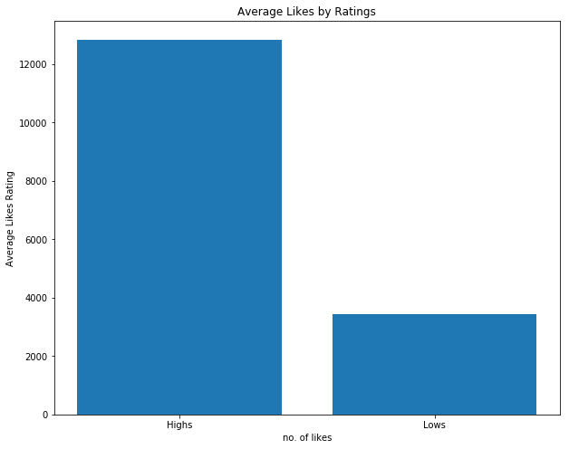

```python
# Comparing the average likes for high and low ratings
locations = [1, 2]
heights = [highs.likes_count.mean(), lows.likes_count.mean()]
labels = ['Highs', 'Lows']
plt.figure(figsize=(10, 8))
plt.bar(locations, heights, tick_label=labels)
plt.title('Average Likes by Ratings')
plt.xlabel('no. of likes')
plt.ylabel('Average Likes Rating');
```

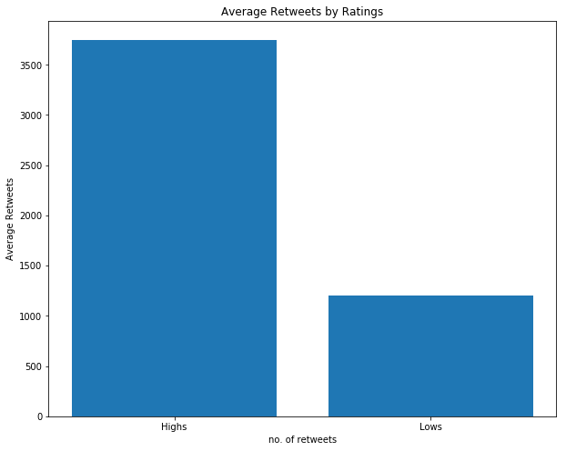

```python
# Comparing the average retweets for high and low ratings
locations = [1, 2]
heights = [highs.retweet_count.mean(), lows.retweet_count.mean()]
labels = ['Highs', 'Lows']
plt.figure(figsize=(10, 8))
plt.bar(locations, heights, tick_label=labels)
plt.title('Average Retweets by Ratings')
plt.xlabel('no. of retweets')
plt.ylabel('Average Retweets');
```

[figure not shown]

```python
# Plot bar chart of top 10 dog breeds
plt.figure(figsize=(15, 8))
top_dogs.plot(kind='barh', color='grey')

# Add labels and title
plt.xlabel('Average Likes', fontsize = 20)
plt.xticks(fontsize = 15)
plt.ylabel('Dog Breed', fontsize = 15)
plt.title('Top Dog Breeds by Likes Count',fontsize = 25);
```

#### Most common dog stage

```python
# view stage count
sub_stages.value.value_counts()
```

```
pupper     143
doggo       57
puppo       20
floofer      8
Name: value, dtype: int64
```

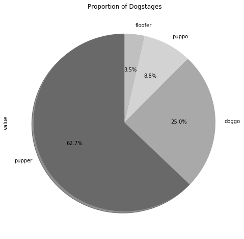

```python
# create pie chart
colors = ['#696969','#A9A9A9','#D3D3D3','#C0C0C0']
plt.figure(figsize=(8,8))
sub_stages['value'].value_counts().plot.pie(autopct='%1.1f%%',colors = colors, shadow=True, startangle=90)
plt.title('Proportion of Dogstages');
```

#### Most used words in tweets

```python
#creating stopwords
STOPWORDS=["HTTPS","https","h t t p s","t","co"]+list(STOPWORDS)
```

```python
text = " ".join(text for text in df.text)
print (len(text))
```

```
172632
```

```python
# import image
image = Image.open("unsplash.jpg")
pup = np.array(image)
```

```python
#generate wordcloud
wordcloud = WordCloud(width = 1000, height = 1000,stopwords=STOPWORDS,
                      min_font_size = 10, mask = pup, background_color="black").generate(text)
```

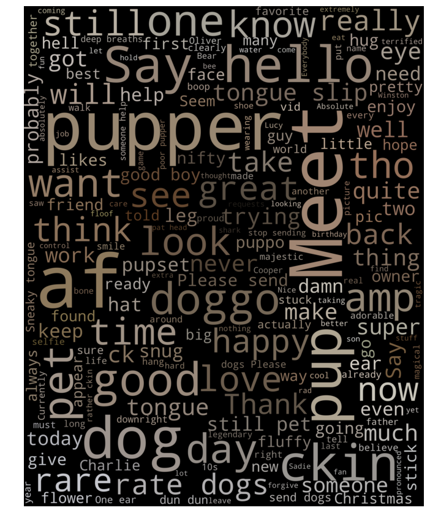

```python
# Display the wordcloud
image_colors = ImageColorGenerator(pup)
plt.figure(figsize=[15,15])
plt.imshow(wordcloud.recolor(color_func=image_colors), interpolation="bilinear")
plt.axis("off")
plt.show()
```